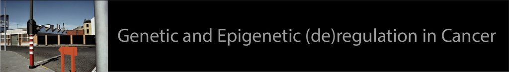

# Publications, software development and scientific communication

orcid.org/0000-0003-3165-3218

## Research articles

[8] Richard, M.*, Decamps, C., Chuffart, F., Brambilla, E., Rousseaux, S., Khochbin, S., Jost, D. (2019) PenDA, a rank-based method for Personalized Differential Analysis: application to lung cancer. Submitted. Download reference datasets

[7] D’Alessandro M, Richard M, Stigloher C, Gache V, Boulin T, Richmond JE, Bessereau JL. (2018) CRELD1 is an evolutionarily-conserved maturational enhancer of ionotropic acetylcholine receptors. Elife. 2018 Nov 7;7. pii: e39649. [Click](https://elifesciences.org/articles/39649)

[6] Salignon #, J., Richard #, M., Fulcrand, E., Duplus-Bottin, H. & Yvert, G. (2018) Genomics of cellular proliferation in periodic environmental fluctuations. Mol Syst Biol. 2018 Mar 5;14(3):e7823. [Click](http://msb.embopress.org.insb.bib.cnrs.fr/content/14/3/e7823.long)

[5] Richard, M.*, Chuffart, F, Duplus-Bottin, H., Pouyet, F., Spichty, M., Fulcrand, E., Entrevan, M., Barthelaix, A., Springer, M., Jost, D., and G. Yvert , G. (2018). Assigning function to natural allelic variation via dynamic modeling of gene network induction. Molecular Systems Biology, 14, e7803. [Click](https://doi.org/10.15252/msb.20177803) or PDF

[4] Chuffart, F., Richard, M., Jost, D., Burny, C., Duplus-Bottin, H., Ohya, Y., & Yvert, G. (2016). Exploiting Single-Cell Quantitative Data to Map Genetic Variants Having Probabilistic Effects. PLoS Genetics, 12(8), e1006213. [Click](http://doi.org/10.1371/journal.pgen.1006213) or PDF

[3] Richard, M. & Yvert, G. L. How does evolution tune biological noise? Front. Genet. 5, 1011 (2014). [Click](http://doi.org/10.3389/fgene.2014.00374) or PDF

[2] Richard, M., Boulin, T., Robert, V. J. P., Richmond, J. E., & Bessereau, J.-L. (2013). Biosynthesis of ionotropic acetylcholine receptors requires the evolutionarily conserved ER membrane complex. Proceedings of the National Academy of Sciences of the United States of America, 110(11), E1055–63. [Click](http://doi.org/10.1073/pnas.1216154110) or PDF

[1] Legent, K., Steinhauer, J., Richard, M., & Treisman, J. E. (2012). A screen for X-linked mutations affecting Drosophila photoreceptor differentiation identifies Casein kinase 1α as an essential negative regulator of wingless signaling. Genetics, 190(2), 601–616. [Click](http://doi.org/10.1534/genetics.111.133827) or PDF

(#): joint first authors

(*): joint corresponding authors

## R packages

4/ dmprocr (2017) P. Terzian, F. Chuffart, D. Jost & **M. Richard**. R package to perform differential methylation profiles clustering.

3/ penda (2017) D. Jost & **M. Richard**. R package to calculate personalized differential analysis of omics data.

2/ facsticor (2015) ) F. Chuffart, G. Yvert & **M. Richard**. R method to analyse flow cytometry single cell data during time course experiments.

1/ h4decoder5 (2013) **M. Richard**. R package to generate error-correcting DNA barcodes.

##Conferences

####2018

ICSB (International Conference of System Biology), Talk, Lyon, France. *PenDA, a rank-based method for personalized differential analysis*

####2017

Epigenetics and Cancer, Poster, Heidelberg, Allemagne. *Identifying epigenetic hotspots in lung cancer*

Advanced lecture course on computational systems biology, Talk, Aussois, France. *Functional Genetic Diversity of the Yeast Galactose Network*

####2016

JOBIM, Poster, Lyon, France. *Functional Genetic Diversity of the Yeast Galactose Network*

####2015

Design optimization and control in system and synthetic biology, Poster, Paris, France. *Functional Genetic Diversity of the Yeast Galactose Network*

BCM Seminar, Invited speaker, Grenoble, France. *Functional Genetic Diversity of the Yeast Galactose Network*

JOBIM, Poster, Clermont-Ferrand. *Identification of fitness advantage in dynamic environment by modelisation of BAR-seq data*

Quatrièmes Rencontres R, Talk, Grenoble, France. *A general method to map single-cell probabilstic trait loci of the genome*

####2014

Experimental Approaches to Evolution and Ecology using Yeast and other Model Systems, Poster, Heidelberg, Germany. *Genetics of fitness in dynamic environments*

Single cells genomics, Poster, Stockholm, Sweden. *Competition between cells in dynamic environments*

####2012

Young Researcher in Life Sciences, Talk, 3rd prize, Paris, France. *Control of acetylcholine receptor maturation and ER homeostasis by a new transmembrane complex*

LBMC Seminar, Invited speaker, Lyon, France. *Control of acetylcholine receptor maturation and ER homeostasis by a new transmembrane complex*

Ver midi, Talk, Paris, France. *Control of acetylcholine receptor maturation and ER homeostasis by a new transmembrane complex*

####2011

18th International Worm Meeting, Poster, Los Angeles, USA. *Control of acetylcholine receptor maturation and ER homeostasis by a new transmembrane complex*

####2010

Neuronal development, synaptic function and behaviour in C. elegans, Poster, Ma- dison, USA. *TMEM-93 is a Conserved Transmembrane Protein Required for Assembly or Stability of Acetylcholine Receptors*

####2009

17th International Worm Meeting, Poster, Los Angeles, USA. *TMEM-93 is a Conserved Transmembrane Protein Required for Assembly or Stability of Acetylcholine Receptors*